# PRAC 2 - Tipología y ciclo de vida de los datos

Autor: Pablo Martín Sánchez - Julia Camarena Pérez

Junio 2021

# PRACTICA 2

Cargamos las librerías necesarias:

```r
library(ggplot2)
library(dplyr)
library(caret)
library(reshape2)
```

```r
titanic_dataset <- read.csv("train.csv", header=TRUE, sep=",", stringsAsFactors=FALSE)
```

## 1. Descripción del dataset

Comprobamos el tipo de variable que tiene el dataset:

```r
str(titanic_dataset)
```

```
## 'data.frame':    891 obs. of  12 variables:
##  $ PassengerId: int  1 2 3 4 5 6 7 8 9 10 ...
##  $ Survived   : int  0 1 1 1 0 0 0 0 1 1 ...
##  $ Pclass     : int  3 1 3 1 3 3 1 3 3 2 ...
##  $ Name       : chr  "Braund, Mr. Owen Harris" "Cumings, Mrs. John Bradley (Florence Briggs Thayer)" "Heikkinen, Miss. Laina" "Futrelle, Mrs. Jacques Heath (Lily May Peel)" ...
##  $ Sex        : chr  "male" "female" "female" "female" ...
##  $ Age        : num  22 38 26 35 35 NA 54 2 27 14 ...
##  $ SibSp      : int  1 1 0 1 0 0 0 3 0 1 ...
##  $ Parch      : int  0 0 0 0 0 0 0 1 2 0 ...
##  $ Ticket     : chr  "A/5 21171" "PC 17599" "STON/O2. 3101282" "113803" ...
##  $ Fare       : num  7.25 71.28 7.92 53.1 8.05 ...
##  $ Cabin      : chr  "" "C85" "" "C123" ...
##  $ Embarked   : chr  "S" "C" "S" "S" ...
```

Miramos las estadísticas basicas de cada atributo:

```r
summary(titanic_dataset)
```

```
##   PassengerId       Survived          Pclass          Name
##  Min.   :  1.0   Min.   :0.0000   Min.   :1.000   Length:891
##  1st Qu.:223.5   1st Qu.:0.0000   1st Qu.:2.000   Class :character
##  Median :446.0   Median :0.0000   Median :3.000   Mode  :character
##  Mean   :446.0   Mean   :0.3838   Mean   :2.309
##  3rd Qu.:668.5   3rd Qu.:1.0000   3rd Qu.:3.000
##  Max.   :891.0   Max.   :1.0000   Max.   :3.000
##
##      Sex                 Age            SibSp           Parch
##  Length:891         Min.   : 0.42   Min.   :0.000   Min.   :0.0000
##  Class :character   1st Qu.:20.12   1st Qu.:0.000   1st Qu.:0.0000
##  Mode  :character   Median :28.00   Median :0.000   Median :0.0000
##                     Mean   :29.70   Mean   :0.523   Mean   :0.3816
##                     3rd Qu.:38.00   3rd Qu.:1.000   3rd Qu.:0.0000
##                     Max.   :80.00   Max.   :8.000   Max.   :6.0000
##                     NA's   :177
##     Ticket               Fare           Cabin             Embarked
##  Length:891         Min.   :  0.00   Length:891         Length:891
##  Class :character   1st Qu.:  7.91   Class :character   Class :character
##  Mode  :character   Median : 14.45   Mode  :character   Mode  :character
##                     Mean   : 32.20
##                     3rd Qu.: 31.00
##                     Max.   :512.33
##
```

## 2 Limpieza de datos

Primero comprobamos si existen nulos o espacios vacíos en el caso de las variables categóricas:

```r
colSums(is.na(titanic_dataset))
```

```
## PassengerId    Survived      Pclass        Name         Sex         Age
##           0           0           0           0           0         177
##       SibSp       Parch      Ticket        Fare       Cabin    Embarked
##           0           0           0           0           0           0
```

```r
colSums(titanic_dataset=="")
```

```
## PassengerId    Survived      Pclass        Name         Sex         Age
##           0           0           0           0           0          NA
##       SibSp       Parch      Ticket        Fare       Cabin    Embarked
##           0           0           0           0         687           2
```

Vemos como obtenemos variables nulas, en el caso de la variable Age, en vez de rellenarlas optaremos por eliminarlas directamente para intentar que no afecte en un futuro a todo lo que haremos en torno a la edad, igual con la variable Embarked.

Ahora miraremos los valores extremos de todas las variables cuantitativas:

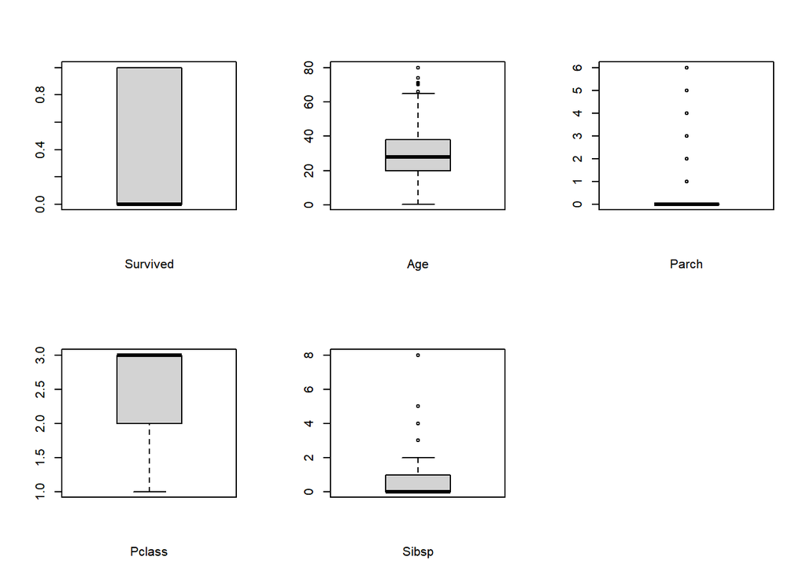

```r
layout(matrix(1:6, ncol=3))

boxplot(titanic_dataset$Survived,xlab="Survived", which=1)

boxplot(titanic_dataset$Pclass,xlab="Pclass", which=2)

boxplot(titanic_dataset$Age, xlab="Age", which = 3)

boxplot(titanic_dataset$SibSp, xlab="Sibsp", which=4)

boxplot(titanic_dataset$Parch, xlab="Parch", which=5)
```

Como podemos observar tenemos algunos valores extremos pero dentro de los valores aceptables para cada caso, como por ejemplo en el número de hermanos (Sibsp) o de hijos(Parch) tenemos outliers como 8 o 6 respectivamente. En el caso de la edad, tenemos algunos por encima de 65 años que no los eliminaremos al no considerarlos outliers a pesar de estar por encima del tercer intercuartil.

Ahora vamos a eliminar todas aquellas filas que tengan la variable Age o Embarked nulas:

```r
titanic_without_na <- titanic_dataset[which(!is.na(titanic_dataset$Age)),]

titanic_without_na <- titanic_without_na[which(titanic_without_na$Embarked!=""),]

colSums(is.na(titanic_without_na))
```

```
## PassengerId    Survived      Pclass        Name         Sex         Age
##           0           0           0           0           0           0
##       SibSp       Parch      Ticket        Fare       Cabin    Embarked
##           0           0           0           0           0           0
```

```r
colSums(titanic_without_na =="")
```

```
## PassengerId    Survived      Pclass        Name         Sex         Age
##           0           0           0           0           0           0
##       SibSp       Parch      Ticket        Fare       Cabin    Embarked
##           0           0           0           0         529           0
```

Se decide categorizar la edad para mirar mas adelante si hay categorías que hayan sobrevivido más que otras.

```r
# Discretizamos
titanic_without_na["Age_Segmented"] <- cut(titanic_without_na$Age, breaks = c(0,10,20,30,40,50,60,70,100), labels = c("0-9", "10-19", "20-29", "30-39","40-49","50-59","60-69","70-79"))
# Observamos los datos discretizados.
head(titanic_without_na)
```

|  | PassengerId | Survived | Pclass | Name | Sex | Age | SibSp | Parch | Ticket | Fare | Cabin | Embarked | Age_Segmented |
| --- | --- | --- | --- | --- | --- | --- | --- | --- | --- | --- | --- | --- | --- |
| 1 | 1 | 0 | 3 | Braund, Mr. Owen Harris | male | 22 | 1 | 0 | A/5 21171 | 7.2500 |  | S | 20-29 |
| 2 | 2 | 1 | 1 | Cumings, Mrs. John Bradley (Florence Briggs Thayer) | female | 38 | 1 | 0 | PC 17599 | 71.2833 | C85 | C | 30-39 |
| 3 | 3 | 1 | 3 | Heikkinen, Miss. Laina | female | 26 | 0 | 0 | STON/O2. 3101282 | 7.9250 |  | S | 20-29 |
| 4 | 4 | 1 | 1 | Futrelle, Mrs. Jacques Heath (Lily May Peel) | female | 35 | 1 | 0 | 113803 | 53.1000 | C123 | S | 30-39 |
| 5 | 5 | 0 | 3 | Allen, Mr. William Henry | male | 35 | 0 | 0 | 373450 | 8.0500 |  | S | 30-39 |
| 7 | 7 | 0 | 1 | McCarthy, Mr. Timothy J | male | 54 | 0 | 0 | 17463 | 51.8625 | E46 | S | 50-59 |

Categorizamos la variable pclass para poder graficarla mejor, clasificando el estatus social en 1-Upper, 2-Middle y 3-Lower.

```r
titanic_without_na$Pclass_categorical <- titanic_without_na$Pclass

titanic_without_na$Pclass_categorical <- gsub("1","Upper",titanic_without_na$Pclass_categorical)

titanic_without_na$Pclass_categorical <- gsub("2","Middle",titanic_without_na$Pclass_categorical)

titanic_without_na$Pclass_categorical <- gsub("3","Lower",titanic_without_na$Pclass_categorical)
```

Convertimos la variable categórica Sex en numérica para poder utilizarla más adelante en correlaciones y crear modelos:

```r
titanic_without_na$Sex_numeric <- titanic_without_na$Sex

titanic_without_na$Sex_numeric <- gsub("male","1",titanic_without_na$Sex_numeric)

titanic_without_na$Sex_numeric <- gsub("female","2",titanic_without_na$Sex_numeric)

titanic_without_na$Sex_numeric <- as.numeric(titanic_without_na$Sex_numeric)


titanic_without_na$Sex_numeric[is.na(titanic_without_na$Sex_numeric)] <- 0
```

Transformarmos la bariable de embarked a numerica para comprobarla más adelante con la correlacion para ver si es importante:

```r
titanic_without_na$Embarked_numeric <- titanic_without_na$Embarked

titanic_without_na$Embarked_numeric <- gsub("C","0",titanic_without_na$Embarked_numeric)

titanic_without_na$Embarked_numeric <- gsub("Q","1",titanic_without_na$Embarked_numeric)

titanic_without_na$Embarked_numeric <- gsub("S","2",titanic_without_na$Embarked_numeric)


titanic_without_na$Embarked_numeric <- as.numeric(titanic_without_na$Embarked_numeric)
```

Categorizamos la variable Survived para poder graficarla comparando con el resto de atributos:

```r
titanic_without_na$Survived_Categorical <- titanic_without_na$Survived

titanic_without_na$Survived_Categorical  <- gsub("1","Yes",titanic_without_na$Survived_Categorical)

titanic_without_na$Survived_Categorical  <- gsub("0","No",titanic_without_na$Survived_Categorical)


head(titanic_without_na)
```

|  | PassengerId | Survived | Pclass | Name | Sex | Age | SibSp | Parch | Ticket | Fare | Cabin | Embarked | Age_Segmented | Pclass_categorical | Sex_numeric | Embarked_numeric | Survived_Categorical |
| --- | --- | --- | --- | --- | --- | --- | --- | --- | --- | --- | --- | --- | --- | --- | --- | --- | --- |
| 1 | 1 | 0 | 3 | Braund, Mr. Owen Harris | male | 22 | 1 | 0 | A/5 21171 | 7.2500 |  | S | 20-29 | Lower | 1 | 2 | No |
| 2 | 2 | 1 | 1 | Cumings, Mrs. John Bradley (Florence Briggs Thayer) | female | 38 | 1 | 0 | PC 17599 | 71.2833 | C85 | C | 30-39 | Upper | 0 | 0 | Yes |
| 3 | 3 | 1 | 3 | Heikkinen, Miss. Laina | female | 26 | 0 | 0 | STON/O2. 3101282 | 7.9250 |  | S | 20-29 | Lower | 0 | 2 | Yes |
| 4 | 4 | 1 | 1 | Futrelle, Mrs. Jacques Heath (Lily May Peel) | female | 35 | 1 | 0 | 113803 | 53.1000 | C123 | S | 30-39 | Upper | 0 | 2 | Yes |
| 5 | 5 | 0 | 3 | Allen, Mr. William Henry | male | 35 | 0 | 0 | 373450 | 8.0500 |  | S | 30-39 | Lower | 1 | 2 | No |
| 7 | 7 | 0 | 1 | McCarthy, Mr. Timothy J | male | 54 | 0 | 0 | 17463 | 51.8625 | E46 | S | 50-59 | Upper | 1 | 2 | No |

Por ultimo, cambiamos las etiquetas de la variable categórica Embarked para que se entienda en que ciudad han embarcado:

```r
titanic_without_na$Embarked <- gsub("C","Cherbourg",  titanic_without_na$Embarked)
titanic_without_na$Embarked <- gsub("Q","Queenstown", titanic_without_na$Embarked)
titanic_without_na$Embarked <- gsub("S","Southampton",titanic_without_na$Embarked)
```

Ahora vamos a comprobar la normalización de las variables numéricas mediante las graficas Q-Q

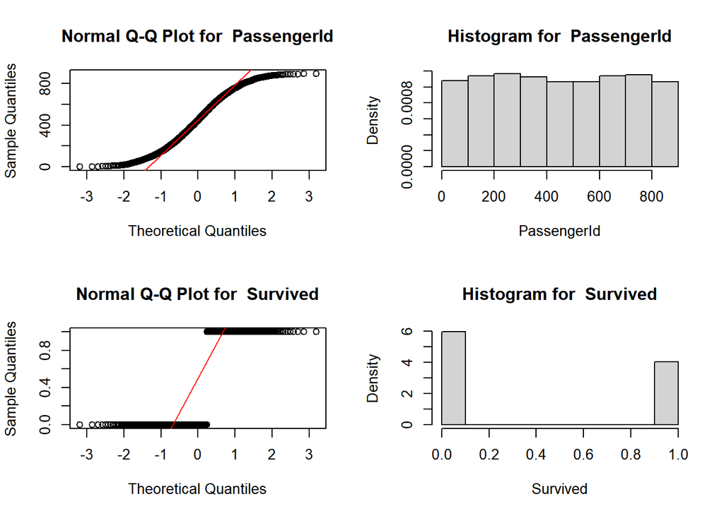

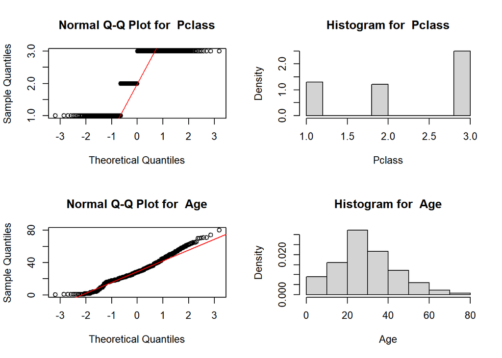

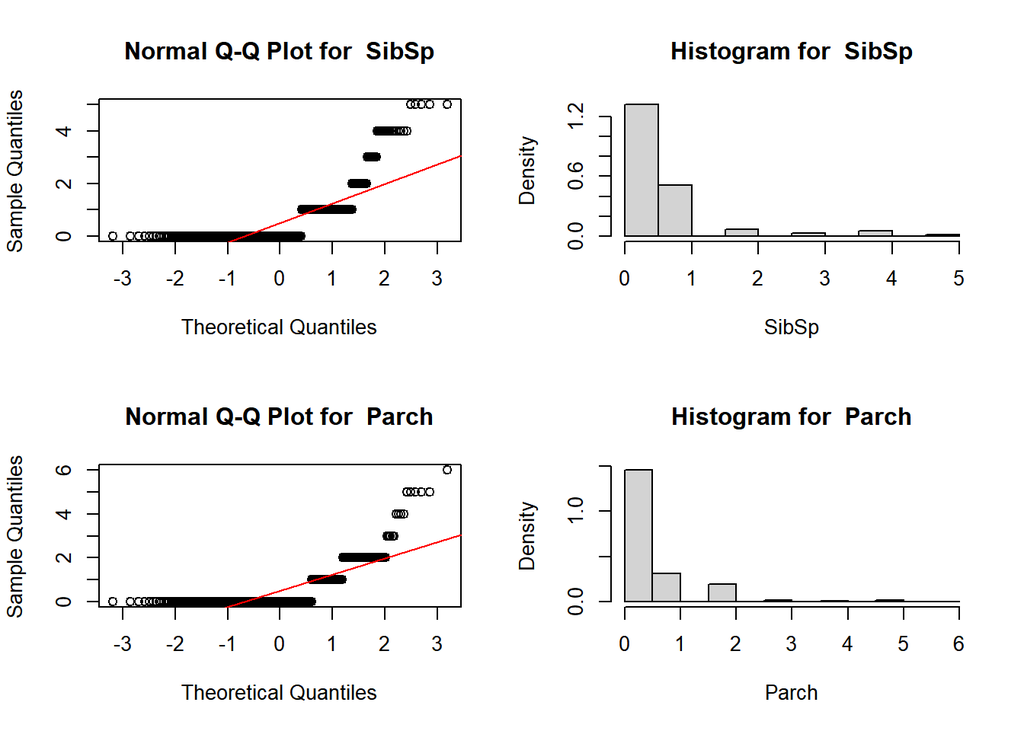

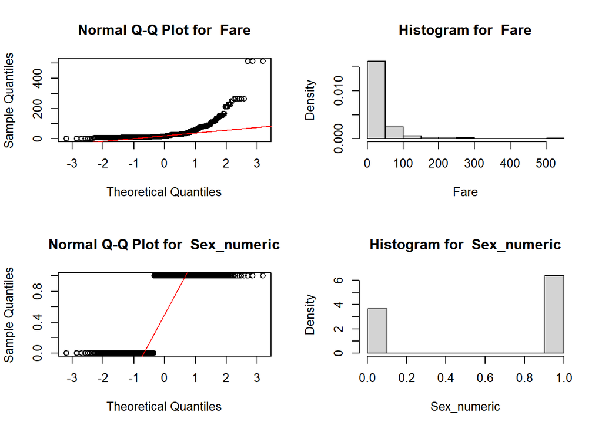

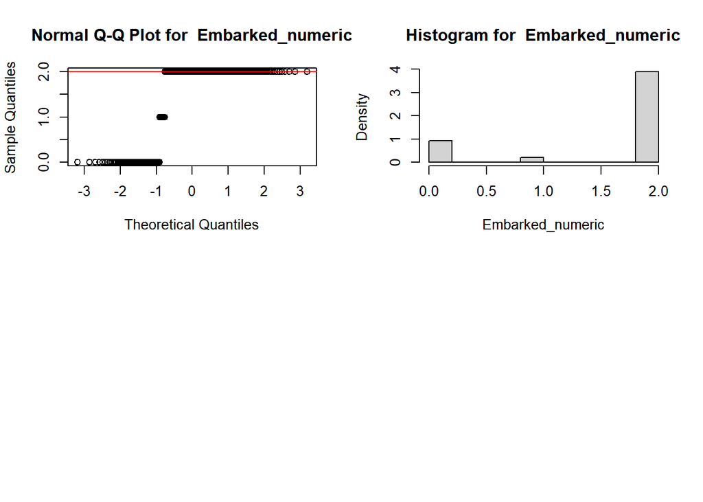

```r
par(mfrow=c(2,2))
for(i in 1:ncol(titanic_without_na)) {
  if (is.numeric(titanic_without_na[,i])){
    qqnorm(titanic_without_na[,i],main = paste("Normal Q-Q Plot for ",colnames(titanic_without_na)[i]))
    qqline(titanic_without_na[,i],col="red")
    hist(titanic_without_na[,i],
      main=paste("Histogram for ", colnames(titanic_without_na)[i]),
      xlab=colnames(titanic_without_na)[i], freq = FALSE)
  }
}
```

Vemos como la mayoría no son normales porque son en realidad variables realmente categóricas ya que indican si el pasajero ha sobrevivido (Survived), la clase social a la que pertenece (Pclass), el número de hermanos o de hijos que tiene (SibSp y Parch) o el propio Sex.

Vamos a guardar el dataframe con todos los datos añadidos y modificados como dataser resultante:

```r
write.csv(titanic_without_na,"titanic_limpio.csv",row.names = FALSE, col.names = TRUE)
```

## 3. Análisis de los datos

### 3.1 Correlación entre variables

Ahora comprobaremos la correlación de las variables para ver cuales tienen mayor importancia sobre la Survived mediante una matriz de correlación:

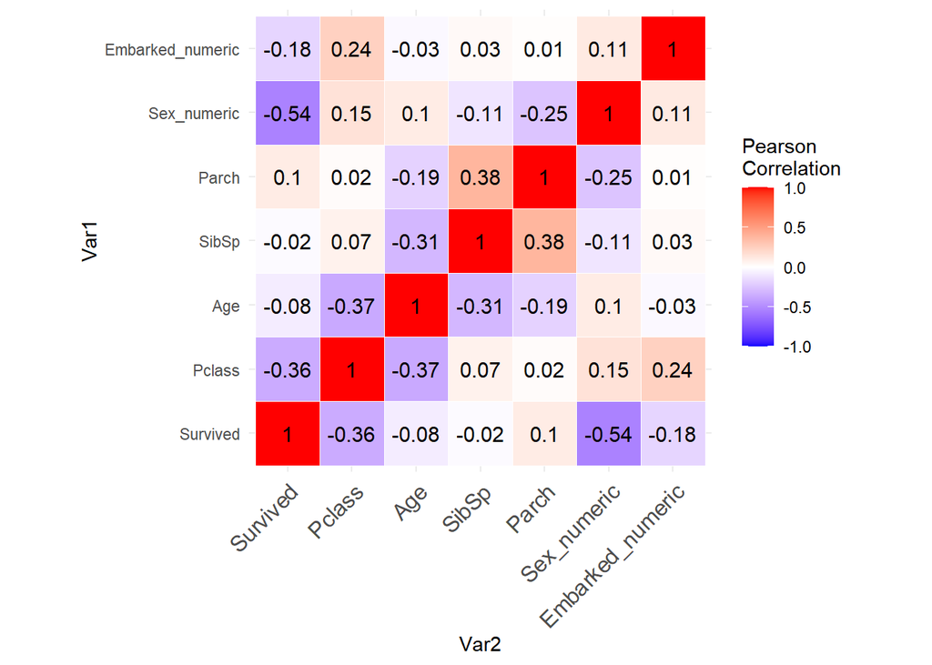

```r
cormat <- round(cor(titanic_without_na[,c(2,3,6,7,8,15,16)]),2)

melted_cormat <- melt(cormat)

ggplot(data = melted_cormat, aes(Var2, Var1, fill = value))+
 geom_tile(color = "white")+
 scale_fill_gradient2(low = "blue", high = "red", mid = "white",
   midpoint = 0, limit = c(-1,1), space = "Lab",
   name="Pearson\nCorrelation") +
  theme_minimal()+
 theme(axis.text.x = element_text(angle = 45, vjust = 1,
    size = 12, hjust = 1))+
 coord_fixed() + geom_text(aes(Var2, Var1, label = value), color = "black", size = 4)
```

Como podemos observar, la variable Sex junto con la Pclass son las que mas influyen a la hora de supervivencia, sobretodo la Sex con un 0.54 de correlación. Es decir, el sexo influye a la hora de sobrevivir.

### 3.2 Contrastes de hipótesis

Ahora vamos a tratar de contestar 3 preguntas mediante el contraste de hipótesis para concretar que grupos han sido los que más han sobrevivido:

1. ¿Han sobrevivido más pasajeros hombres que mujeres?
2. ¿Han sobrevivido más pasajeros menores de <= 30 años que mayores de 30?
3. ¿Han sobrevivido más pasajeros de clase alta que de clase media y baja?

Vamos con la primera pregunta:

1. ¿Han sobrevivido más pasajeros hombres que mujeres?

   m0 : pasajeros que han sobrevivido hombres m1 : pasajeros que han sobrevivido mujeres

   H0 = m0 <= m1 H1 = m0 > m1

```r
survived_male <- titanic_without_na[which(titanic_without_na$Sex == 'male'),"Survived"]


survived_female <- titanic_without_na[which(titanic_without_na$Sex == 'female'),"Survived"]

t.test(survived_male, survived_female, alternative = "greater")
```

```
##
##  Welch Two Sample t-test
##
## data:  survived_male and survived_female
## t = -16.647, df = 508.24, p-value = 1
## alternative hypothesis: true difference in means is greater than 0
## 95 percent confidence interval:
##  -0.6018033        Inf
## sample estimates:
## mean of x mean of y
## 0.2052980 0.7528958
```

Tras aplicar el contraste de hipótesis, aceptamos la hipótesis nula, ya que el pvalue>0,05 (teniendo en cuenta que hemos escogido un porcentaje de confianza del 95%). Afirmamos por tanto, que sobrevivieron más mujeres que hombres.

2. ¿Han sobrevivido más personas menores de <= 30 años que mayores de 30?

   m0 : pasajeros de menos de 30 años o de 30 años que han sobrevivido m1 : pasajeros de mas de 30 años que han sobrevivido

   H0 = m0 <= m1 H1 = m0 > m1

```r
survived_le_thirty <- titanic_without_na[which(titanic_without_na$Age <= 30),"Survived"]


survived_g_thirty <- titanic_without_na[which(titanic_without_na$Age > 30),"Survived"]

t.test(survived_le_thirty, survived_g_thirty, alternative = "greater")
```

```
##
##  Welch Two Sample t-test
##
## data:  survived_le_thirty and survived_g_thirty
## t = 0.086653, df = 651.12, p-value = 0.4655
## alternative hypothesis: true difference in means is greater than 0
## 95 percent confidence interval:
##  -0.05812801         Inf
## sample estimates:
## mean of x mean of y
## 0.4058680 0.4026403
```

3. ¿Han sobrevivido más pasajeros de clase alta que de clase media y baja?

   m0 : pasajeros que han sobrevivido de clase alta m1 : pasajeros que han sobrevivido de clase media y baja

   H0 = m0 <= m1 H1 = m0 > m1

```r
survived_upper_class <- titanic_without_na[which(titanic_without_na$Pclass_categorical == 'Upper'),"Survived"]

survived_medium_lower_class <- titanic_without_na[which(titanic_without_na$Pclass_categorical != 'Upper'),"Survived"]

t.test(survived_upper_class, survived_medium_lower_class, alternative = "greater")
```

```
##
##  Welch Two Sample t-test
##
## data:  survived_upper_class and survived_medium_lower_class
## t = 8.2192, df = 312.75, p-value = 2.755e-15
## alternative hypothesis: true difference in means is greater than 0
## 95 percent confidence interval:
##  0.2669543       Inf
## sample estimates:
## mean of x mean of y
## 0.6521739 0.3181818
```

Rechazamos la hipótesis nula al ser el p-value inferior a nuestra alpha, que en este caso es 0.05. Por tanto podemos afirmar que han sobrevivido mas pasajeros de clase alta que de clase media y baja

### 3.3 Modelo predictivo

Vamos a tratar de crear un modelo de regresión logística para ver si podemos crear un modelo suficientemente bueno que pueda predecir aquellos que puedan sobrevivir y ver así mediante los coeficienes de odds, ver aquellas categorías que más han sobrevivido. Pondremos como variable dependiente la variable Survived:

```r
model <- glm(titanic_without_na$Survived ~ titanic_without_na$Pclass_categorical + titanic_without_na$Age_Segmented + titanic_without_na$Sex, family = binomial(link=logit))
```

```r
summary(model)
```

```
##
## Call:
## glm(formula = titanic_without_na$Survived ~ titanic_without_na$Pclass_categorical +
##     titanic_without_na$Age_Segmented + titanic_without_na$Sex,
##     family = binomial(link = logit))
##
## Deviance Residuals:
##     Min       1Q   Median       3Q      Max
## -2.7968  -0.7259  -0.4145   0.6468   2.4543
##
## Coefficients:
##                                             Estimate Std. Error z value
## (Intercept)                                   1.4263     0.3373   4.229
## titanic_without_na$Pclass_categoricalMiddle   1.2122     0.2462   4.925
## titanic_without_na$Pclass_categoricalUpper    2.4647     0.2773   8.889
## titanic_without_na$Age_Segmented10-19        -1.1159     0.3977  -2.806
## titanic_without_na$Age_Segmented20-29        -1.3077     0.3589  -3.643
## titanic_without_na$Age_Segmented30-39        -1.1804     0.3828  -3.084
## titanic_without_na$Age_Segmented40-49        -1.8576     0.4347  -4.273
## titanic_without_na$Age_Segmented50-59        -2.1197     0.5377  -3.942
## titanic_without_na$Age_Segmented60-69        -2.7525     0.7930  -3.471
## titanic_without_na$Age_Segmented70-79        -2.1661     1.2438  -1.742
## titanic_without_na$Sexmale                   -2.5300     0.2097 -12.067
##                                             Pr(>|z|)
## (Intercept)                                 2.35e-05 ***
## titanic_without_na$Pclass_categoricalMiddle 8.45e-07 ***
## titanic_without_na$Pclass_categoricalUpper   < 2e-16 ***
## titanic_without_na$Age_Segmented10-19       0.005018 **
## titanic_without_na$Age_Segmented20-29       0.000269 ***
## titanic_without_na$Age_Segmented30-39       0.002044 **
## titanic_without_na$Age_Segmented40-49       1.93e-05 ***
## titanic_without_na$Age_Segmented50-59       8.07e-05 ***
## titanic_without_na$Age_Segmented60-69       0.000518 ***
## titanic_without_na$Age_Segmented70-79       0.081582 .
## titanic_without_na$Sexmale                   < 2e-16 ***
## ---
## Signif. codes:  0 '***' 0.001 '**' 0.01 '*' 0.05 '.' 0.1 ' ' 1
##
## (Dispersion parameter for binomial family taken to be 1)
##
##     Null deviance: 960.90  on 711  degrees of freedom
## Residual deviance: 643.45  on 701  degrees of freedom
## AIC: 665.45
##
## Number of Fisher Scoring iterations: 5
```

```r
exp(coefficients(model))
```

```
##                                 (Intercept)
##                                  4.16307894
## titanic_without_na$Pclass_categoricalMiddle
##                                  3.36103157
##  titanic_without_na$Pclass_categoricalUpper
##                                 11.75954661
##       titanic_without_na$Age_Segmented10-19
##                                  0.32761064
##       titanic_without_na$Age_Segmented20-29
##                                  0.27044393
##       titanic_without_na$Age_Segmented30-39
##                                  0.30716384
##       titanic_without_na$Age_Segmented40-49
##                                  0.15604453
##       titanic_without_na$Age_Segmented50-59
##                                  0.12007010
##       titanic_without_na$Age_Segmented60-69
##                                  0.06376534
##       titanic_without_na$Age_Segmented70-79
##                                  0.11462289
##                  titanic_without_na$Sexmale
##                                  0.07966004
```

## 4 Visualización de los datos

Pasamos a hacer una breve visualización de los datos, para comprobar en las variables categóricas aquellas clases que más han sobrevivido y, así, confirmar si las conclusiones que hemos ido obteniendo anteriormente se confirman.

Mostramos primero como hemos visto con la correlación, si el sexo importa a la hora de sobrevivir:

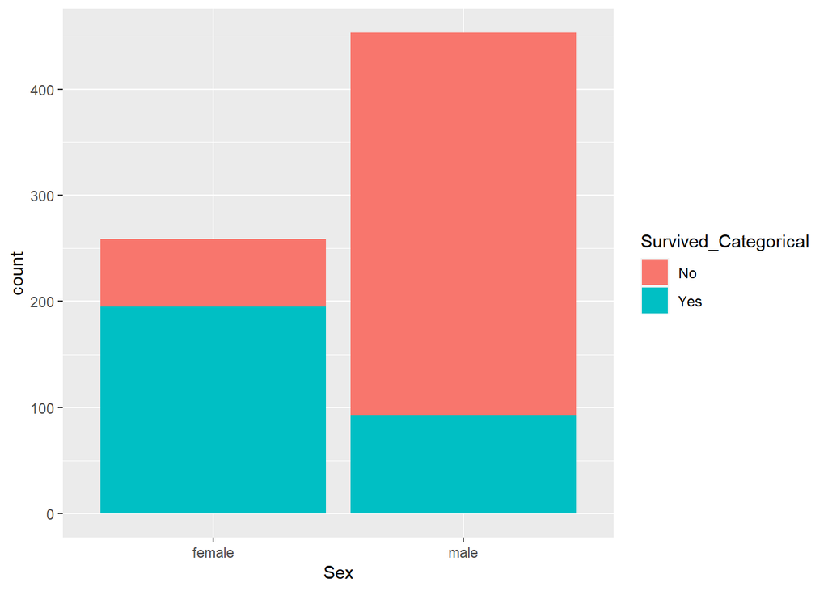

```r
filas=dim(titanic_without_na)[1]
# Visualizamos la relación entre las variables "sex" y "survival":
ggplot(data=titanic_without_na[1:filas,],aes(x=Sex,fill=Survived_Categorical))+geom_bar()
```

Como podemos observar, se ve claramente como sobrevivieron más mujeres que hombres, confirmando la observación de la correlación en la que el sexo era importante a la hora de la supervivencia.

Ahora vamos a comprobar la clase social para ver si lo que nos indicaba las hipótesis inferidas anterioremente:

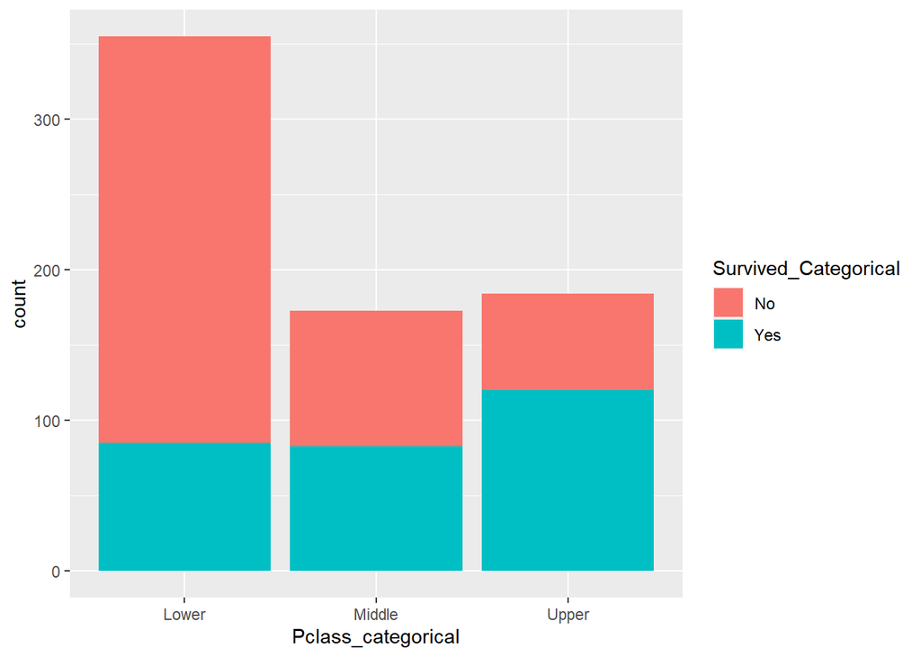

```r
filas=dim(titanic_without_na)[1]
# Visualizamos la relación entre las variables "sex" y "survival":
ggplot(data=titanic_without_na[1:filas,],aes(x=Pclass_categorical,fill=Survived_Categorical))+geom_bar()
```

Podemos observar como claramente de clase alta ha sobrevivido mucha mas gente que de clase media y baja, confirmando que nuestra hipótesis inferida era correcta.

Ahora miremos para concretar si la franja de edad es influyente:

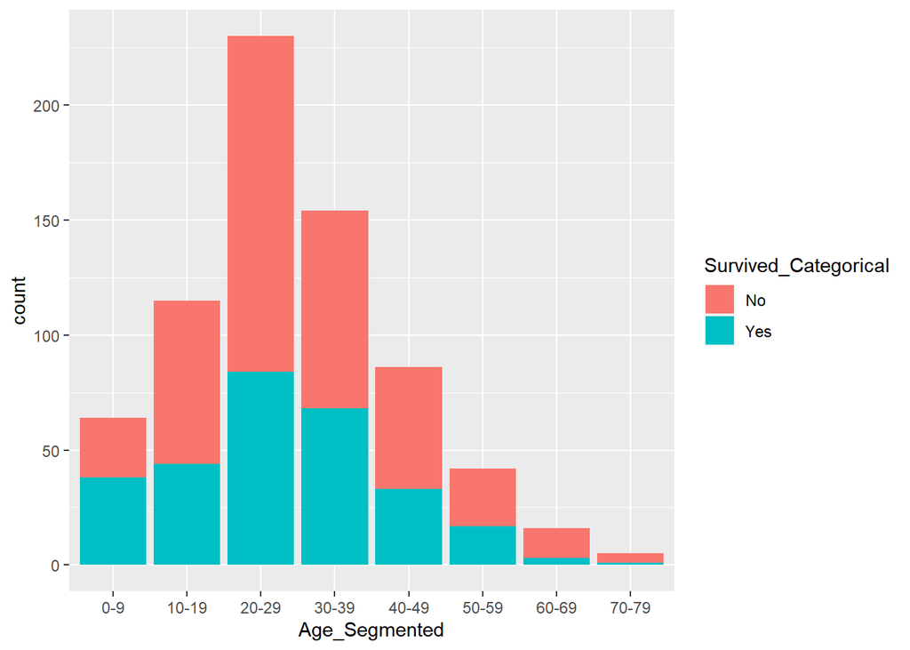

```r
filas=dim(titanic_without_na)[1]
# Visualizamos la relación entre las variables "sex" y "survival":
ggplot(data=titanic_without_na[1:filas,],aes(x=Age_Segmented,fill=Survived_Categorical))+geom_bar()
```

Ahora vamos a comprobar también si el lugar de embarque, a pesar de no tener una correlación aparente, hay algo interesante:

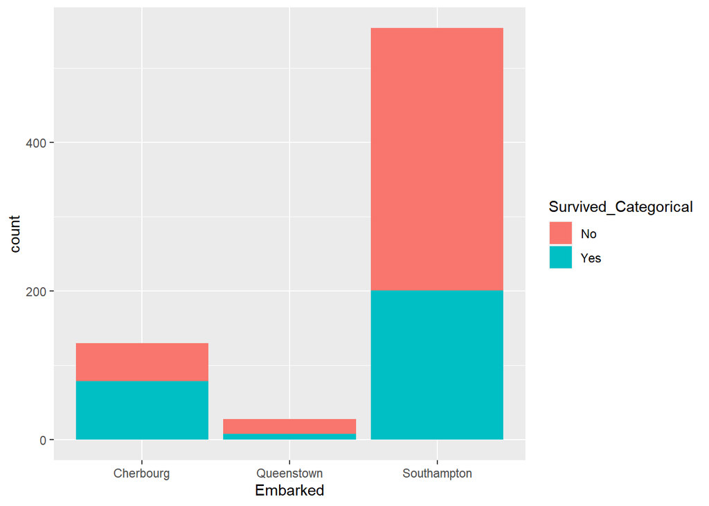

```r
filas=dim(titanic_without_na)[1]
# Visualizamos la relación entre las variables "sex" y "survival":
ggplot(data=titanic_without_na[1:filas,],aes(x=Embarked,fill=Survived_Categorical))+geom_bar()
```

Como podemos observar, el lugar no es influyente en realidad aun que parezca que de Cherbourg hayan sobrevivido mas que de Queenstown o Southampton, ya que son otros los factores determinantes como el sexo o la clase social. Es decir, es posible por ejemplo que de Cherbourg haya mas mujeres de clase alta.

## 5. Conclusiones

Tras haber realizado el análisis de los datos hemos llegado a algunas conclusiones. En primer lugar, hemos observado mediante la prueba de correlación y comprobado más tarde mediante la regresión logística que la variable más influyente en si los pasajeros del Titanic sobrevivieron es sex, seguida de la variable pclass.

Finalmente, mediante su odds ratio hemos visto que los pasajeros de clase Medium y Upper sobrevivieron más que los de clase Lower de la variable pclass. También que sobrevivieron más mujeres que hombres y que el grupo de edad de personas que más sobrevivieron es el de 0 a 9 años.